# EasyVisa_Full_Code_Notebook_final

### Data Preparation for modeling

We need to convert categorical variables into numerical format using one-hot encoding, and then split the data into training and testing sets. The case_id column will be dropped as it is an identifier and not useful for modeling. The target variable case_status will be encoded.

```python
df = df.drop('case_id', axis=1)

df_encode = pd.get_dummies(df,
                           columns=['continent', 'education_of_employee', 'has_job_experience', 'requires_job_training', 'region_of_employment', 'unit_of_wage', 'full_time_position'],
                           drop_first=True)

label_encoder = LabelEncoder()
df_encode['case_status'] = label_encoder.fit_transform(df_encode['case_status'])

X = df_encode.drop('case_status', axis=1)
y = df_encode['case_status']

X_train, X_test, y_train, y_test = train_test_split(X, y, test_size=0.3, random_state=42, stratify=y)

print("Shape of X_train:", X_train.shape)
print("Shape of y_train:", y_train.shape)
print("Shape of X_test:", X_test.shape)
print("Shape of y_test:", y_test.shape)
```

```
Shape of X_train: (17836, 21)
Shape of y_train: (17836,)
Shape of X_test: (7644, 21)
Shape of y_test: (7644,)
```

## Model Building

### Model Evaluation Criterion

The model_performance_classification_sklearn function will be used to check the model performance of models.

The confusion_matrix_sklearn function will be used to plot the confusion matrix.

Helper functions, model_performance_classification_sklearn and confusion_matrix_sklearn, will be used to consistently assess model performance and visualize results.

First, let's create functions to calculate different metrics and confusion matrix so that we don't have to use the same code repeatedly for each model.

- The `model_performance_classification_sklearn` function will be used to check the model performance of models.
- The `confusion_matrix_sklearn` function will be used to plot the confusion matrix.

```python
# defining a function to compute different metrics to check performance of a classification model built using sklearn


def model_performance_classification_sklearn(model, predictors, target):
    """
    Function to compute different metrics to check classification model performance

    model: classifier
    predictors: independent variables
    target: dependent variable
    """

    # predicting using the independent variables
    pred = model.predict(predictors)

    acc = accuracy_score(target, pred)  # to compute Accuracy
    recall = recall_score(target, pred)  # to compute Recall
    precision = precision_score(target, pred)  # to compute Precision
    f1 = f1_score(target, pred)  # to compute F1-score

    # creating a dataframe of metrics
    df_perf = pd.DataFrame(
        {"Accuracy": acc, "Recall": recall, "Precision": precision, "F1": f1,},
        index=[0],
    )

    return df_perf
```

```python
def confusion_matrix_sklearn(model, predictors, target):
    """
    To plot the confusion_matrix with percentages

    model: classifier
    predictors: independent variables
    target: dependent variable
    """
    y_pred = model.predict(predictors)
    cm = confusion_matrix(target, y_pred)
    labels = np.asarray(
        [
            ["{0:0.0f}".format(item) + "\n{0:.2%}".format(item / cm.flatten().sum())]
            for item in cm.flatten()
        ]
    ).reshape(2, 2)

    plt.figure(figsize=(6, 4))
    sns.heatmap(cm, annot=labels, fmt="")
    plt.ylabel("True label")
    plt.xlabel("Predicted label")
```

#### Defining scorer to be used for cross-validation and hyperparameter tuning

```python
scorer = 'recall'
```

**We are now done with pre-processing and evaluation criterion, so let's start building the model.**

### Model building with Original data

I will develop five classification models using the original unbalanced training dataset: Decision Tree, Random Forest, Bagging Classifier, AdaBoost, and Gradient Boosting.

```
Train original data: Decision Tree
Train performance for: Decision Tree
   Accuracy  Recall  Precision   F1
0       1.0     1.0        1.0  1.0
```

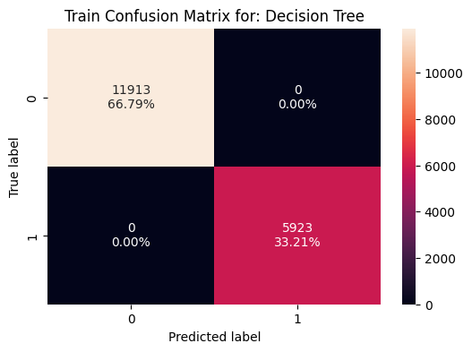

```
Test performance for: Decision Tree
   Accuracy    Recall  Precision        F1
0  0.649529  0.496258   0.473684  0.484709
```

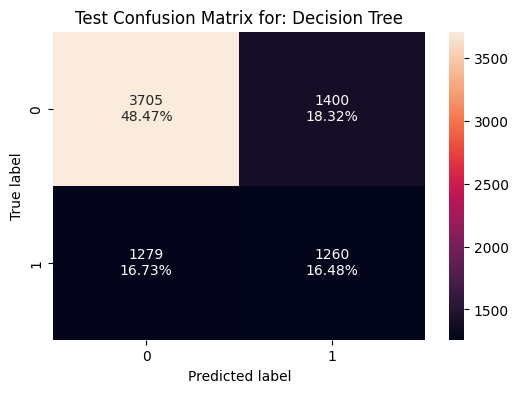

```
Train original data: Random Forest
Train performance for: Random Forest
   Accuracy  Recall  Precision   F1
0       1.0     1.0        1.0  1.0
```

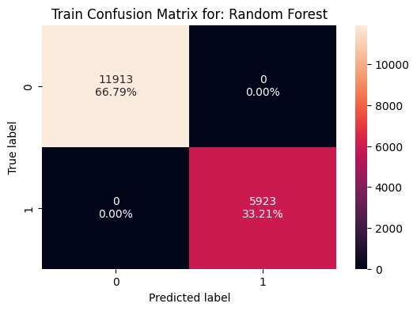

```
Test performance for: Random Forest
   Accuracy    Recall  Precision        F1
0   0.72776  0.483261   0.614729  0.541125
```

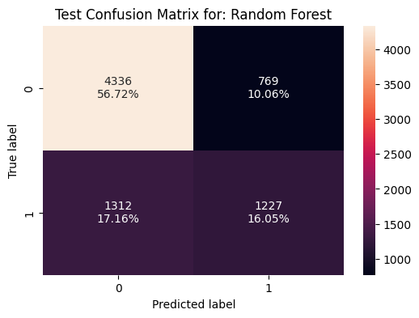

```
Train original data: Bagging Classifier
Train performance for: Bagging Classifier
   Accuracy    Recall  Precision        F1
0  0.977742  0.941584   0.990938  0.965631
```

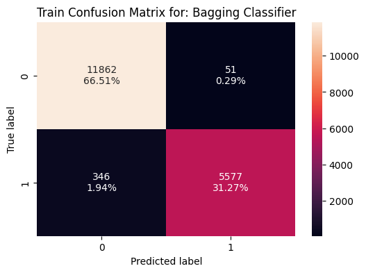

```
Test performance for: Bagging Classifier
   Accuracy    Recall  Precision        F1
0  0.712585  0.419063   0.595745  0.492023
```

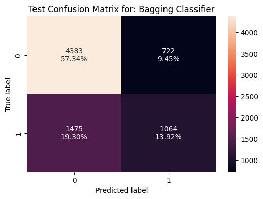

```
Train original data: AdaBoost
Train performance for: AdaBoost
   Accuracy    Recall  Precision        F1
0  0.737553  0.439642   0.656581  0.526646
```

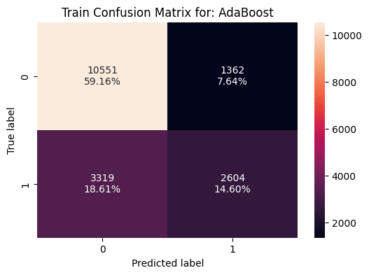

```
Test performance for: AdaBoost
   Accuracy    Recall  Precision        F1
0  0.742151  0.446239   0.667256  0.534812
```

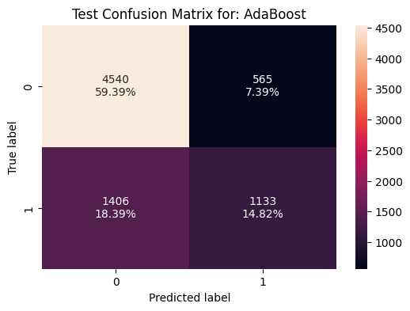

```
Train original data: Gradient Boosting
Train performance for: Gradient Boosting
   Accuracy    Recall  Precision        F1
0   0.75471  0.504643   0.674718  0.577417
```

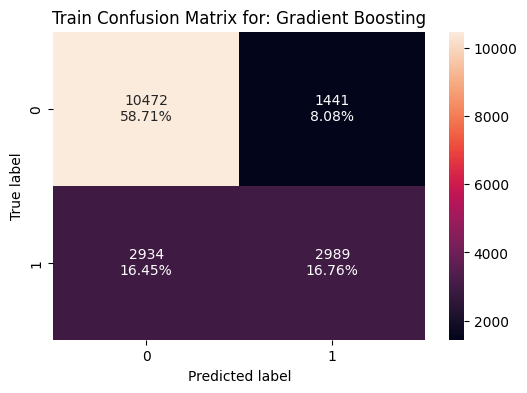

```
Test performance for: Gradient Boosting
   Accuracy    Recall  Precision        F1
0  0.753401  0.498228   0.674307  0.573046
```

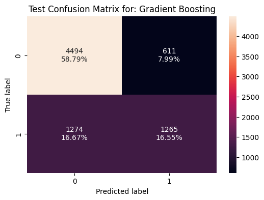

```python
models = {
    'Decision Tree': DecisionTreeClassifier(random_state=42),
    'Random Forest': RandomForestClassifier(random_state=42),
    'Bagging Classifier': BaggingClassifier(random_state=42),
    'AdaBoost': AdaBoostClassifier(random_state=42, algorithm='SAMME'),
    'Gradient Boosting': GradientBoostingClassifier(random_state=42)
}

original_model_performance = {}

for name, model in models.items():
    print(f"Train original data: {name}")
    model.fit(X_train, y_train)

    train_perf = model_performance_classification_sklearn(model, X_train, y_train)
    print(f"Train performance for: {name}")
    print(train_perf)
    confusion_matrix_sklearn(model, X_train, y_train)
    plt.title(f'Train Confusion Matrix for: {name}')
    plt.show()

    test_perf = model_performance_classification_sklearn(model, X_test, y_test)
    print(f"Test performance for: {name}")
    print(test_perf)
    confusion_matrix_sklearn(model, X_test, y_test)
    plt.title(f'Test Confusion Matrix for: {name}')
    plt.show()

    original_model_performance[name] = {'train': train_perf, 'test': test_perf}
    print("\n\n\n")
```

### Model Building with Oversampled data

To address the class imbalance, we will apply SMOTE (Synthetic Minority Over-sampling Technique) to the training data, oversampling the 'Denied' class. Subsequently, the five classification models will be trained on this balanced dataset.

```
Shape of X_train_oversampled: (23826, 21)
Value counts of y_train_oversampled:  1    11913
0    11913
Name: case_status, dtype: int64
Train on oversampled data: Decision Tree
Train performance for Decision Tree (Oversampled):
   Accuracy  Recall  Precision   F1
0       1.0     1.0        1.0  1.0
```

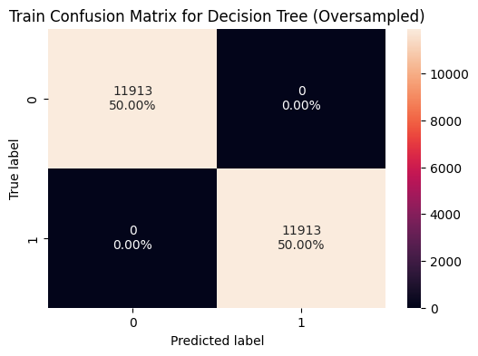

```
Test performance for Decision Tree (Oversampled):
   Accuracy    Recall  Precision       F1
0  0.655939  0.519102   0.483315  0.50057
```

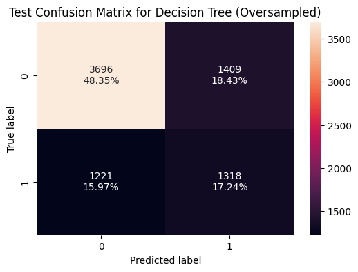

```
Train on oversampled data: Random Forest
Train performance for Random Forest (Oversampled):
   Accuracy  Recall  Precision   F1
0       1.0     1.0        1.0  1.0
```

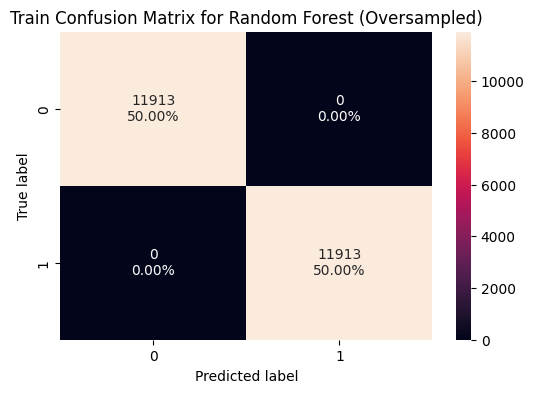

```
Test performance for Random Forest (Oversampled):
   Accuracy   Recall  Precision        F1
0  0.723443  0.54037   0.591634  0.564841
```

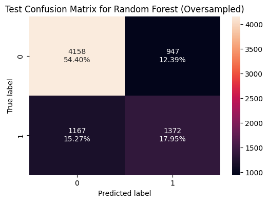

```
Train on oversampled data: Bagging Classifier
Train performance for Bagging Classifier (Oversampled):
   Accuracy    Recall  Precision        F1
0  0.983589  0.973223   0.993828  0.983417
```

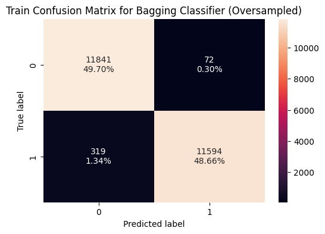

```
Test performance for Bagging Classifier (Oversampled):
   Accuracy    Recall  Precision       F1
0  0.704474  0.479716   0.564935  0.51885
```

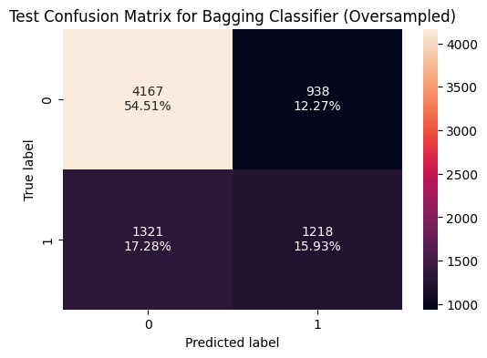

```
Train on oversampled data: AdaBoost
Train performance for AdaBoost (Oversampled):
   Accuracy    Recall  Precision        F1
0  0.758919  0.771006   0.752807  0.761798
```

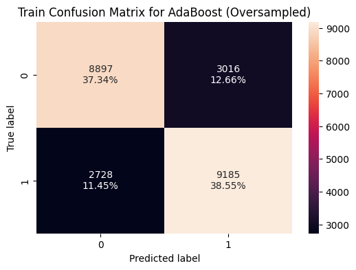

```
Test performance for AdaBoost (Oversampled):
   Accuracy   Recall  Precision        F1
0  0.691654  0.57503   0.533236  0.553345
```

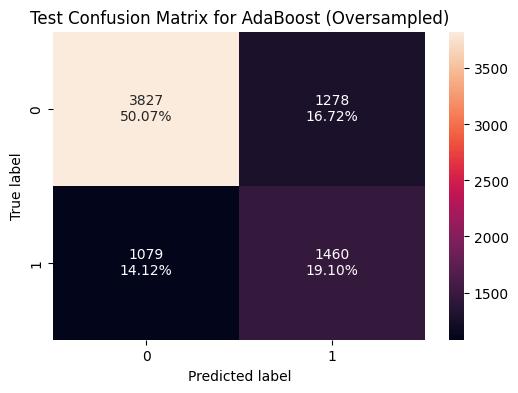

```
Train on oversampled data: Gradient Boosting
Train performance for Gradient Boosting (Oversampled):
   Accuracy    Recall  Precision        F1
0  0.798749  0.782255   0.808941  0.795374
```

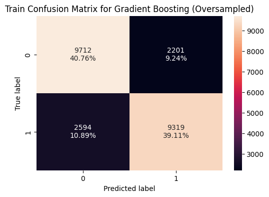

```
Test performance for Gradient Boosting (Oversampled):
   Accuracy   Recall  Precision        F1
0  0.736525  0.58015   0.608426  0.593952
```

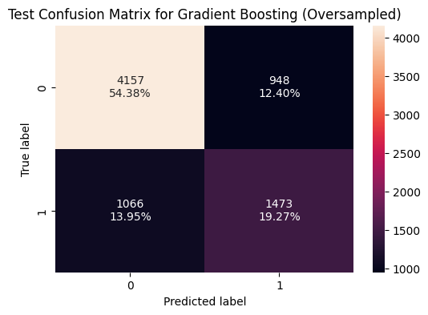

```python
smote = SMOTE(random_state=42)
X_train_oversampled, y_train_oversampled = smote.fit_resample(X_train, y_train)
print("Shape of X_train_oversampled:", X_train_oversampled.shape)
print("Value counts of y_train_oversampled: ", y_train_oversampled.value_counts())

oversampled_model_performance = {}
for name, model in models.items():
    print(f"Train on oversampled data: {name}")
    model.fit(X_train_oversampled, y_train_oversampled)

    train_perf = model_performance_classification_sklearn(model, X_train_oversampled, y_train_oversampled)
    print(f"Train performance for {name} (Oversampled):")
    print(train_perf)
    confusion_matrix_sklearn(model, X_train_oversampled, y_train_oversampled)
    plt.title(f'Train Confusion Matrix for {name} (Oversampled)')
    plt.show()

    test_perf = model_performance_classification_sklearn(model, X_test, y_test)
    print(f"Test performance for {name} (Oversampled):")
    print(test_perf)
    confusion_matrix_sklearn(model, X_test, y_test)
    plt.title(f'Test Confusion Matrix for {name} (Oversampled)')
    plt.show()

    oversampled_model_performance[name] = {'train': train_perf, 'test': test_perf}
    print("\n\n\n")
```